# P5

Luis Domínguez

2024-03-20

## Práctica 5

En el aula virtual se encuentran los archivos `X.csv`, `Y.csv`, `Z.csv`.

```r
library(readr)
X <- read_csv("./X.csv")
Y <- read_csv("./Y.csv")
Z <- read_csv("./Z.csv")
```

### (1) Una serie de tiempo integrada, `Xt`

- **a) Carga en R los datos del archivo.** Los datos contienen una serie de tiempo `X.csv`. Llama a esta serie de tiempo `Xt`.

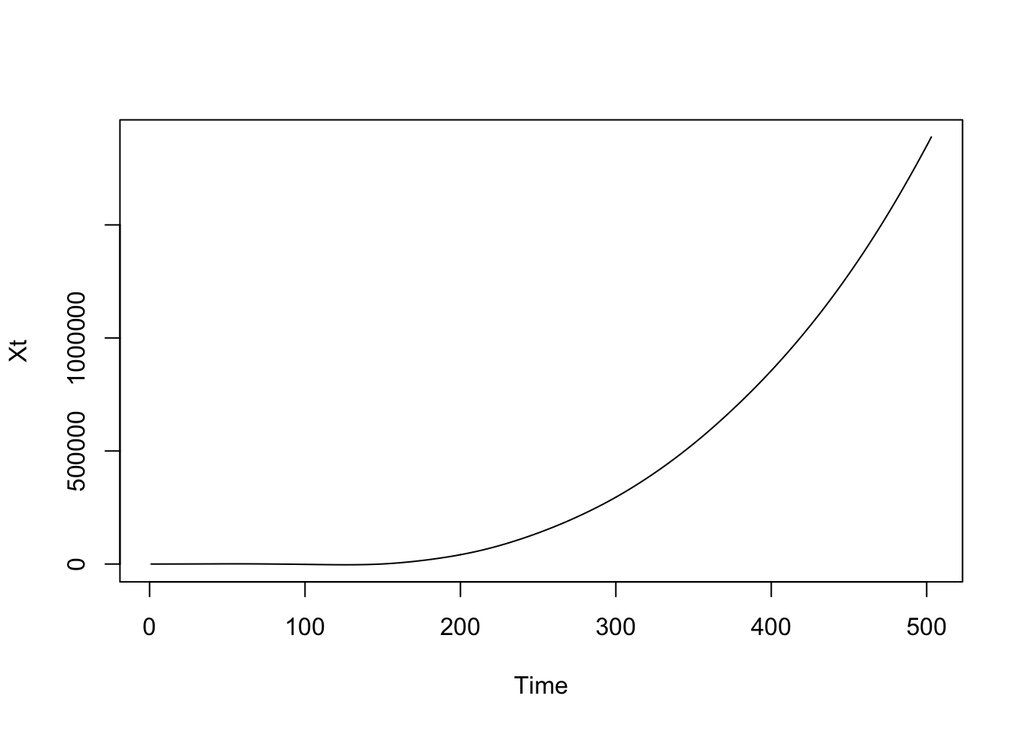

```r
Xt<-as.ts(X)
ts.plot(Xt)
```

- **b) Determina si `Xt` es estacionaria o no.** Explica por qué es o no es estacionaria.

```r
adf.test(Xt)
```

```
##
##  Augmented Dickey-Fuller Test
##
## data:  Xt
## Dickey-Fuller = 2.4954, Lag order = 7, p-value = 0.99
## alternative hypothesis: stationary
```

Al ser mayor que 0.5, no es estacionaria

- **c) Convierte a la serie de tiempo en una serie de tiempo estacionaria.** Explica tu procedimiento.

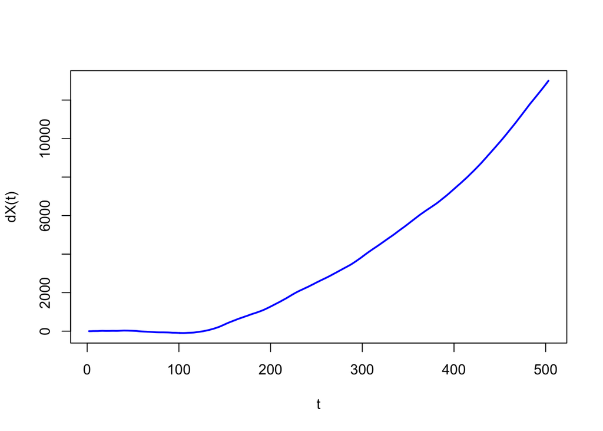

```r
dX1<-diff(Xt)
plot(dX1, type="l", col="blue", lwd=2, xlab="t", ylab="dX(t)")
```

```r
adf.test(dX1)
```

```
##
##  Augmented Dickey-Fuller Test
##
## data:  dX1
## Dickey-Fuller = -0.08691, Lag order = 7, p-value = 0.99
## alternative hypothesis: stationary
```

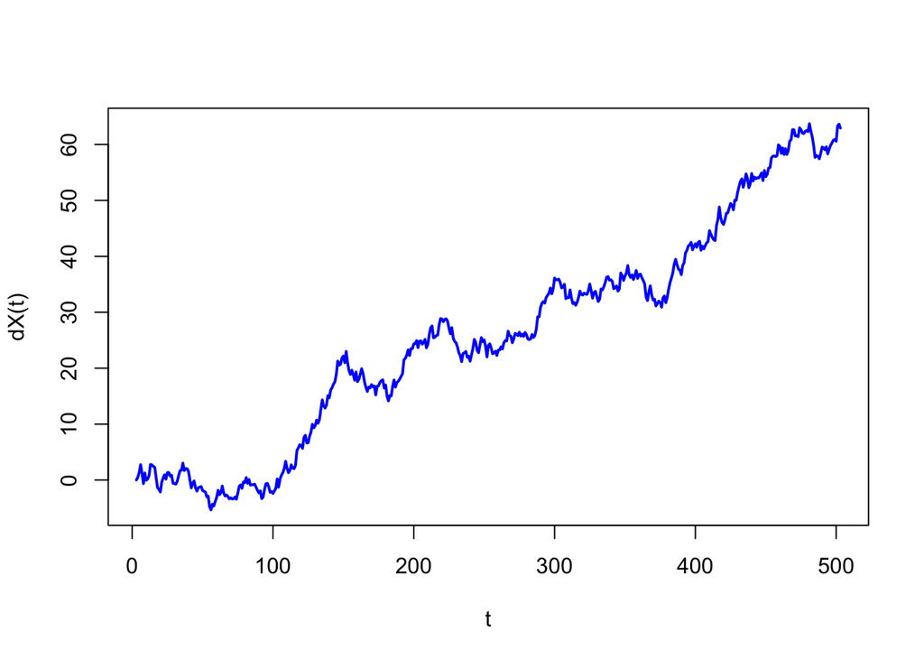

```r
dX2<-diff(dX1)
plot(dX2, type="l", col="blue", lwd=2, xlab="t", ylab="dX(t)")
```

```r
adf.test(dX2)
```

```
##
##  Augmented Dickey-Fuller Test
##
## data:  dX2
## Dickey-Fuller = -2.6162, Lag order = 7, p-value = 0.3175
## alternative hypothesis: stationary
```

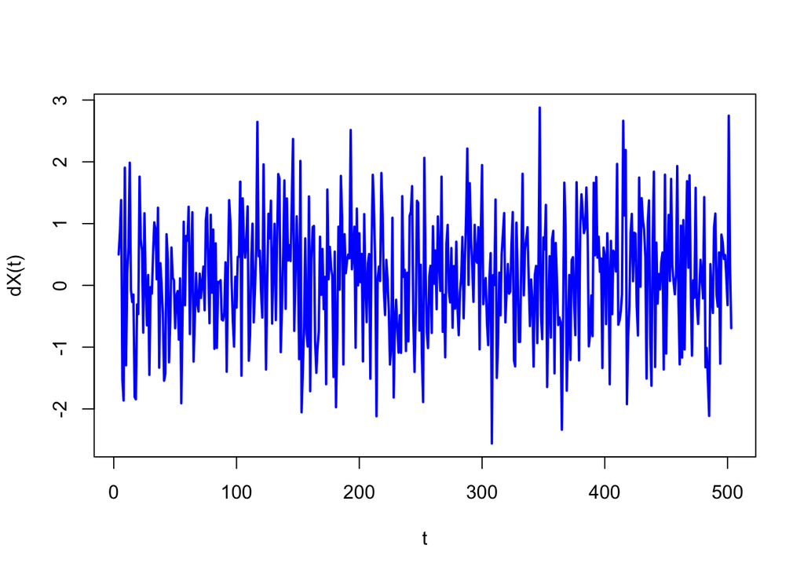

```r
dX3<-diff(dX2)
plot(dX3, type="l", col="blue", lwd=2, xlab="t", ylab="dX(t)")
```

```r
adf.test(dX3)
```

```
##
##  Augmented Dickey-Fuller Test
##
## data:  dX3
## Dickey-Fuller = -7.2976, Lag order = 7, p-value = 0.01
## alternative hypothesis: stationary
```

Se integró 3 veces la función para que sea estacionaria. Una vez alcanzado el p-value menor a 0.05, se puede decir que ya lo es.

- **d) Concluye que `Xt` es integrada de orden `d`, `I(d)`.** ¿Cuál es el valor de `d`?

Xt es integrada de orden 3. I(3)

Realiza el mismo ejercicio para `Yt`, `Zt`.

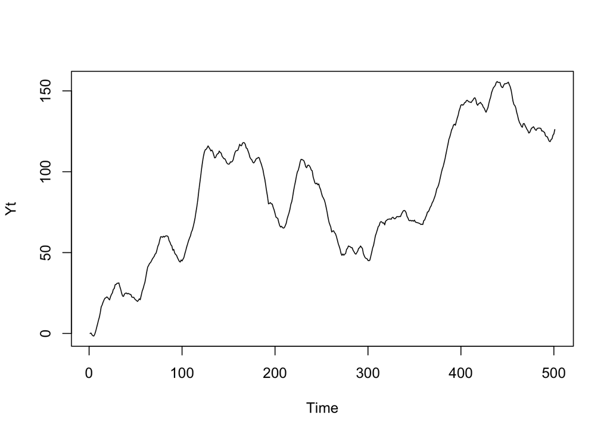

```r
Yt<-as.ts(Y)
ts.plot(Yt)
```

```r
adf.test(Yt)
```

```
##
##  Augmented Dickey-Fuller Test
##
## data:  Yt
## Dickey-Fuller = -2.4272, Lag order = 7, p-value = 0.3975
## alternative hypothesis: stationary
```

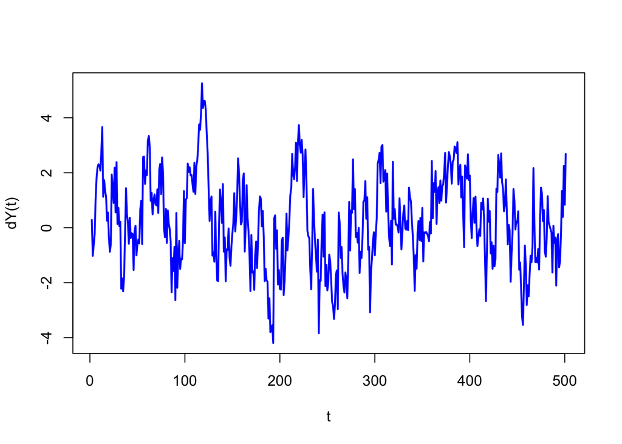

```r
dY1<-diff(Yt)
plot(dY1, type="l", col="blue", lwd=2, xlab="t", ylab="dY(t)")
```

```r
adf.test(dY1)
```

```
##
##  Augmented Dickey-Fuller Test
##
## data:  dY1
## Dickey-Fuller = -4.748, Lag order = 7, p-value = 0.01
## alternative hypothesis: stationary
```

Se integró 1 vez la función para que sea estacionaria. Una vez alcanzado el p-value menor a 0.05, se puede decir que ya lo es. Yt es integrada de orden 1. I(1)

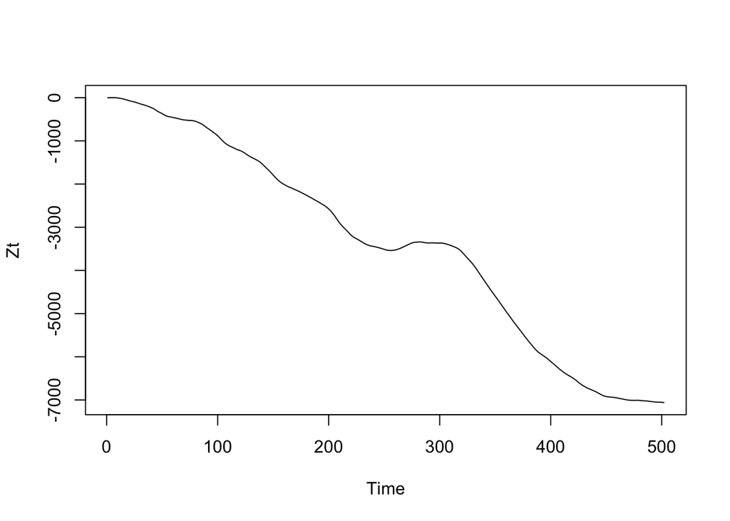

```r
Zt<-as.ts(Z)
ts.plot(Zt)
```

```r
adf.test(Zt)
```

```
##
##  Augmented Dickey-Fuller Test
##
## data:  Zt
## Dickey-Fuller = -3.1318, Lag order = 7, p-value = 0.09969
## alternative hypothesis: stationary
```

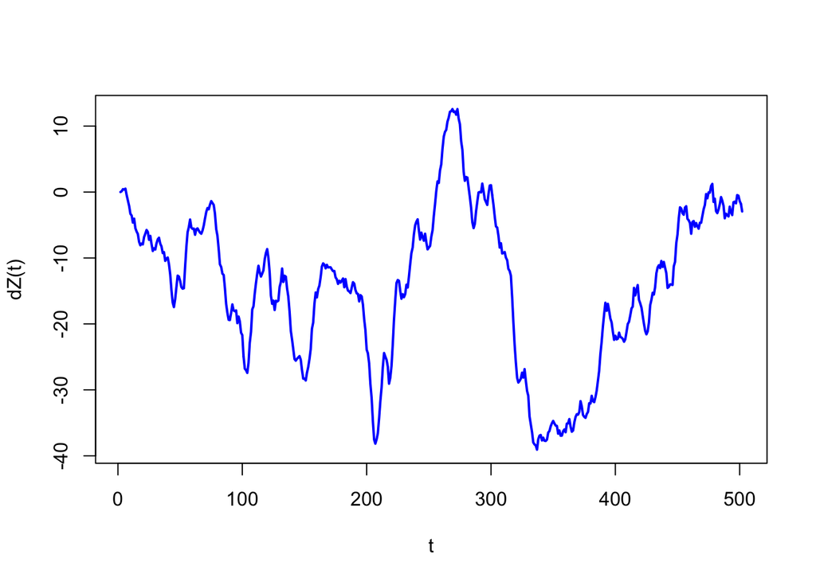

```r
dZ1<-diff(Zt)
plot(dZ1, type="l", col="blue", lwd=2, xlab="t", ylab="dZ(t)")
```

```r
adf.test(dZ1)
```

```
##
##  Augmented Dickey-Fuller Test
##
## data:  dZ1
## Dickey-Fuller = -2.4633, Lag order = 7, p-value = 0.3822
## alternative hypothesis: stationary
```

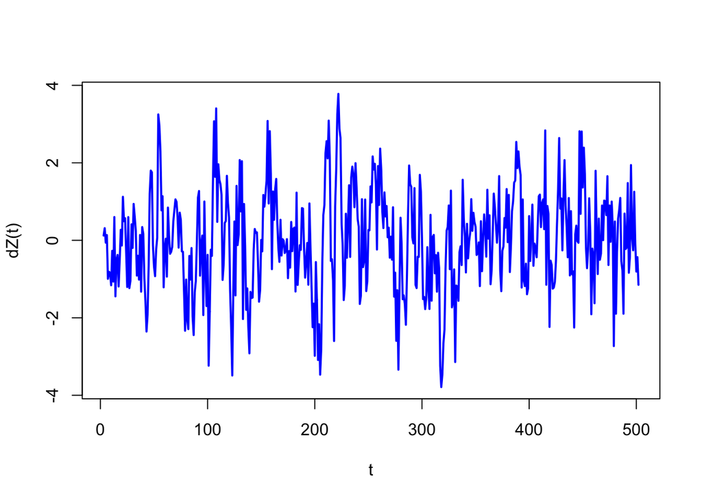

```r
dZ2<-diff(dZ1)
plot(dZ2, type="l", col="blue", lwd=2, xlab="t", ylab="dZ(t)")
```

```r
adf.test(dZ2)
```

```
##
##  Augmented Dickey-Fuller Test
##
## data:  dZ2
## Dickey-Fuller = -7.1554, Lag order = 7, p-value = 0.01
## alternative hypothesis: stationary
```

Se integró 2 veces la función para que sea estacionaria. Una vez alcanzado el p-value menor a 0.05, se puede decir que ya lo es. Zt es integrada de orden 2. I(2)

### (2) La serie de tiempo `Yt`

- **a) Una vez que tu serie de tiempo `Yt` sea estacionaria, llama a esta nueva serie de tiempo, `Pt` (realiza un cambio de variable).** Grafica las funciones `acf` y `pacf` de `Pt`. Pide a R que escriba los valores numéricos de las funciones `acf` y `pacf` de `Pt`.

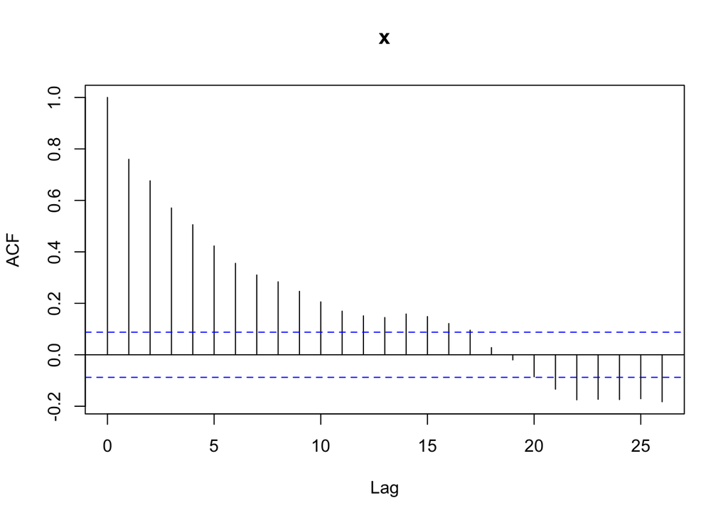

```r
Pt<-dY1
acfP<-acf(Pt)
```

```r
acfP
```

```
##
## Autocorrelations of series 'Pt', by lag
##
##      0      1      2      3      4      5      6      7      8      9     10
##  1.000  0.760  0.676  0.570  0.505  0.423  0.355  0.310  0.283  0.247  0.206
##     11     12     13     14     15     16     17     18     19     20     21
##  0.170  0.151  0.145  0.158  0.148  0.121  0.096  0.028 -0.020 -0.085 -0.134
##     22     23     24     25     26
## -0.175 -0.173 -0.174 -0.171 -0.183
```

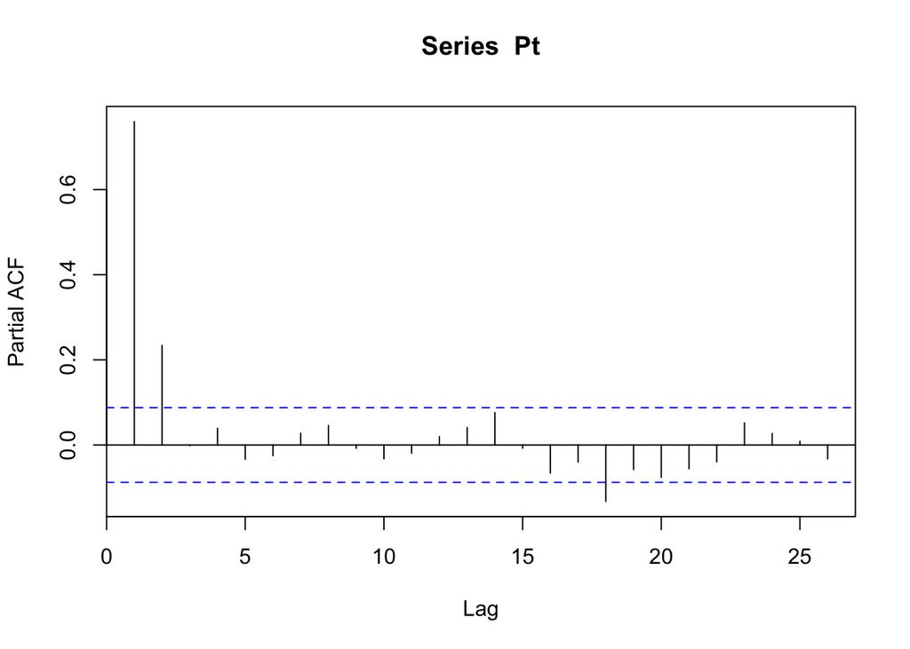

```r
pacfP<-pacf(Pt)
```

```r
pacfP
```

```
##
## Partial autocorrelations of series 'Pt', by lag
##
##      1      2      3      4      5      6      7      8      9     10     11
##  0.760  0.234 -0.002  0.039 -0.033 -0.025  0.028  0.046 -0.008 -0.032 -0.019
##     12     13     14     15     16     17     18     19     20     21     22
##  0.020  0.041  0.076 -0.007 -0.066 -0.040 -0.132 -0.058 -0.076 -0.056 -0.039
##     23     24     25     26
##  0.052  0.027  0.009 -0.033
```

- **b) Revisa la `acf` y `pacf` de `Pt` para determinar qué modelo de serie de tiempo podría ser el que generó a `Pt`.** Justifica por qué podría ser un `AR(p)` y determina de qué orden sería.

Al observar la PACF, se puede concluir que podría ser un`AR(2)`

- **c) Conclusión:** Concluye que la serie original `Yt` es candidata a ser un `ARIMA(p, d, q)` y escribe los valores de `p`, `d`, `q`.

```r
auto.arima(Yt)
```

```
## Series: Yt
## ARIMA(2,1,0)
##
## Coefficients:
##          ar1     ar2
##       0.5866  0.2351
## s.e.  0.0436  0.0436
##
## sigma^2 = 1.05:  log likelihood = -721.27
## AIC=1448.54   AICc=1448.59   BIC=1461.19
```

Por lo tanto, p=2, d=1, q=0

### (3) La serie de tiempo `Zt`

- **a) Una vez que tu serie de tiempo `Zt` sea estacionaria, llama a esta nueva serie de tiempo, `Ht` (realiza un cambio de variable).** Grafica las funciones `acf` y `pacf` de `Ht`. Pide a R que escriba los valores numéricos de las funciones `acf` y `pacf` de `Ht`.

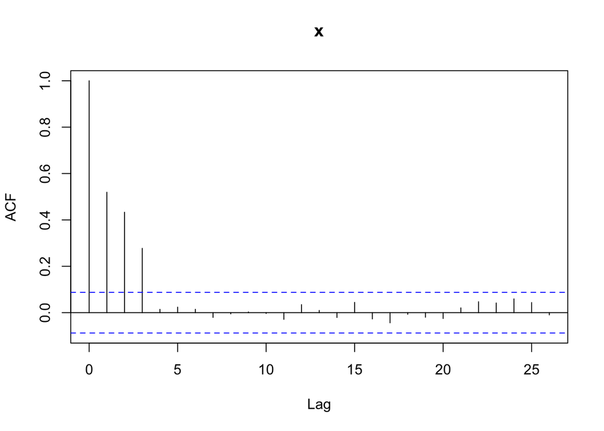

```r
Ht<-dZ2
acfH<-acf(Ht)
```

```r
acfH
```

```
##
## Autocorrelations of series 'Ht', by lag
##
##      0      1      2      3      4      5      6      7      8      9     10
##  1.000  0.519  0.433  0.277  0.014  0.024  0.015 -0.021 -0.005  0.003 -0.003
##     11     12     13     14     15     16     17     18     19     20     21
## -0.029  0.035  0.010 -0.021  0.044 -0.027 -0.044 -0.007 -0.020 -0.025  0.021
##     22     23     24     25     26
##  0.047  0.042  0.059  0.044 -0.010
```

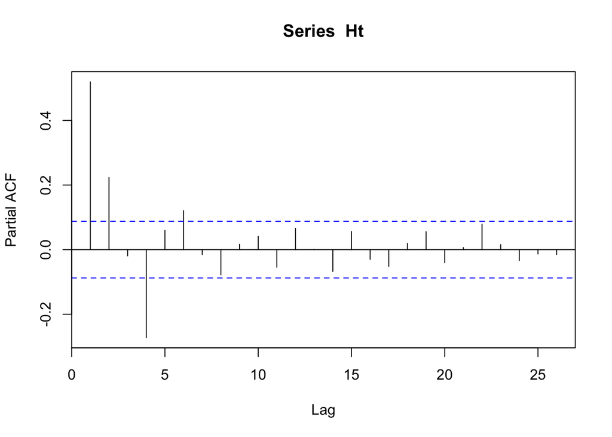

```r
pacfH<-pacf(Ht)
```

```r
pacfH
```

```
##
## Partial autocorrelations of series 'Ht', by lag
##
##      1      2      3      4      5      6      7      8      9     10     11
##  0.519  0.224 -0.019 -0.272  0.059  0.121 -0.016 -0.078  0.017  0.041 -0.054
##     12     13     14     15     16     17     18     19     20     21     22
##  0.066  0.001 -0.067  0.056 -0.030 -0.052  0.019  0.056 -0.040  0.007  0.079
##     23     24     25     26
##  0.016 -0.034 -0.013 -0.015
```

- **b) Revisa la `acf` y `pacf` de `Ht` para determinar qué modelo de serie de tiempo podría ser el que generó a `Ht`.** Justifica por qué podría ser un `MA(q)` y determina de qué orden sería.

- **c) Conclusión:** Concluye que la serie original `Zt` es candidata a ser un `ARIMA(p, d, q)` y escribe los valores de `p`, `d`, `q`.

```r
auto.arima(Zt)
```

```
## Series: Zt
## ARIMA(4,2,2)
##
## Coefficients:
##          ar1      ar2     ar3      ar4     ma1     ma2
##       0.2792  -0.0736  0.2900  -0.1845  0.1336  0.4633
## s.e.  0.1280   0.1031  0.0721   0.0554  0.1285  0.0981
##
## sigma^2 = 1.071:  log likelihood = -724.06
## AIC=1462.12   AICc=1462.35   BIC=1491.63
```

Por lo tanto, p=4, d=2, q=2